# Analisi_mercato_immobiliare_texas

Davide Incaini

2024-08-22

## 1-Importa il dataset “Real Estate Texas.csv”,contenente dei dati riguardanti le vendite di immobili in Texas

```r
#Importa il dataset
data = read.csv("realestate_texas.csv")
attach(data)

head(data)
```

```
##       city year month sales volume median_price listings months_inventory
## 1 Beaumont 2010     1    83 14.162       163800     1533              9.5
## 2 Beaumont 2010     2   108 17.690       138200     1586             10.0
## 3 Beaumont 2010     3   182 28.701       122400     1689             10.6
## 4 Beaumont 2010     4   200 26.819       123200     1708             10.6
## 5 Beaumont 2010     5   202 28.833       123100     1771             10.9
## 6 Beaumont 2010     6   189 27.219       122800     1803             11.1
```

## 2-Indica il tipo di variabili contenute nel dataset.

#### (Attenzione alle variabili che sottintendono il tempo e a come vengono trattate!)

```r
#Importo la libreria knitr per utilizzare la funzione kable
#La funzione kable mi permette di creare tabelle formatatte in markdown
library(knitr)
library(kableExtra)
library(dplyr)

#Usa la funzione sapply per applicare la funzione typeof
#a ciascuna colonna del dataset, determinando così il tipo di ciascuna variabile.
#Viene creata poi una tabella utilizzando kable con le colonne Variable e Type


variable_type = kable(sapply(data,typeof),col.names = c("Variable","Type")) %>%
  kable_styling(
    full_width = FALSE,
    bootstrap_options = c("striped", "hover", "condensed", "responsive")
  ) %>%
  row_spec(0, bold = TRUE, color = "white", background = "#2A3F54")

variable_type
```

| Variable | Type |
| --- | --- |
| city | character |
| year | integer |
| month | integer |
| sales | integer |
| volume | double |
| median_price | double |
| listings | integer |
| months_inventory | double |

## 3-Calcola Indici di posizione, variabilità e forma per tutte le variabili per le quali ha senso farlo,per le altre crea una distribuzione di frequenza.Commenta tutto brevemente.

```r
library(moments) #libreria per per calcolare la curtosi
library(dplyr)

#crea un data frame dedicato selezionando le colonne ritenute da me più adatte
#al calcolo degli indici di posizione e variabilità

data_indici = data %>%
  select (sales,volume, median_price,listings,months_inventory)


attach(data_indici)

# Funzione per calcolare indici statistici del dataset data_indici scelto selezionando le variabili più adatte ad essere rappresentate con gli indici di posizione e variabilità.
calcola_indici = function(data_indici) {

  # Inizializza una lista per memorizzare i risultati
  indici = list()

  # Itera attraverso ogni colonna del dataset
  for (col in names(data_indici)) {
    # Verifica che la colonna sia numerica
    if (is.numeric(data_indici[[col]])) {

      # Calcola gli indici di posizione, variabilità e forma
      range_val = round(range(data_indici[[col]], na.rm = TRUE),2)
      media = round(mean(data_indici[[col]], na.rm = TRUE),2)
      mediana = round(median(data_indici[[col]], na.rm = TRUE),2)
      varianza = round(var(data_indici[[col]], na.rm = TRUE),2)
      dev_standard = round(sd(data_indici[[col]], na.rm = TRUE),2)
      coeff_variazione_percentuale =
      round(sd(data_indici[[col]], na.rm = TRUE)/mean(data_indici[[col]],        na.rm = TRUE)*100,2)
      Q1_val = round (quantile(data_indici[[col]],0.25,na.rm = TRUE),2)
      Q3_val = round (quantile(data_indici[[col]],0.75,na.rm = TRUE),2)
      IQR_val = round(IQR(data_indici[[col]], na.rm = TRUE),2)
      asimmetria = round(skewness(data_indici[[col]], na.rm = TRUE),2)
      curtosi = round(kurtosis(data_indici[[col]], na.rm = TRUE),2)-3

      # Memorizza i risultati in una lista
      indici[[col]] = list(

        range = range_val,
        media = media,
        mediana = mediana,
        varianza = varianza,
        dev_standard = dev_standard,
        CV  = coeff_variazione_percentuale,
        Q1 = Q1_val,
        Q3 = Q3_val,
        IQR = IQR_val,
        asimmetria = asimmetria,
        curtosi = curtosi
      )
    }
  }

   # Converte la lista di risultati in un dataframe

   #lapply(indici, function(x) data.frame(t(x))) applica la funzione a ciascun elemento
   #della lista indici dove sono contenuti gli indici per ogni variabile
   #infine traspone ogni elemento convertendolo in un oggetto di tipo dataframe
   # do.call(rbind, ...) combina questi data frame per riga in un unico data frame.
  indici_df = do.call(rbind, lapply(indici, function(x) data.frame(t(x))))

  # Ritorna il dataframe con i risultati
  return(indici_df)
}

#Applica la funzione alla lista che ci siamo creati contente tutti gli indici necessari
indici = calcola_indici(data_indici)

indici %>%
  kable(align = "c") %>%
  kable_styling(
    full_width = FALSE,
    bootstrap_options = c("striped", "hover", "condensed", "responsive")
  ) %>%
  row_spec(0, bold = TRUE, color = "white", background = "#2A3F54")
```

|  | range | media | mediana | varianza | dev_standard | CV | Q1 | Q3 | IQR | asimmetria | curtosi |
| --- | --- | --- | --- | --- | --- | --- | --- | --- | --- | --- | --- |
| sales | 79, 423 | 192.29 | 175.5 | 6344.3 | 79.65 | 41.42 | 127 | 247 | 120 | 0.72 | -0.31 |
| volume | 8.17, 83.55 | 31.01 | 27.06 | 277.27 | 16.65 | 53.71 | 17.66 | 40.89 | 23.23 | 0.88 | 0.18 |
| median_price | 73800, 180000 | 132665.4 | 134500 | 513572983 | 22662.15 | 17.08 | 117300 | 150050 | 32750 | -0.36 | -0.62 |
| listings | 743, 3296 | 1738.02 | 1618.5 | 566569 | 752.71 | 43.31 | 1026.5 | 2056 | 1029.5 | 0.65 | -0.79 |
| months_inventory | 3.4, 14.9 | 9.19 | 8.95 | 5.31 | 2.3 | 25.06 | 7.8 | 10.95 | 3.15 | 0.04 | -0.17 |

#### Le variabili sales, volume e listings mostrano una dispersione molto elevata ed una media superiore alla mediana. Si nota di conseguenza un’asimmetria positiva.

## 3.1-Per le altre crea una distribuzione di frequenza.

```r
# Crea il data frame selezionando le variabili che non sono state ritenute adatte al calcolo degli indici
data_distrib_freq = data %>%
  select(city, year, month)

# Funzione per calcolare e visualizzare le distribuzioni di frequenza
calculate_and_display_freq = function(df, column_name) {
  # Calcolo delle frequenze assolute e relative
  freq_ass = table(df[[column_name]])
  freq_rel = prop.table(freq_ass)

  # Unisce le frequenze assolute e relative
  distrib_freq = rbind(freq_ass, freq_rel)

  distrib_freq %>%
    kable(align = "c", digits = 2) %>%
    kable_styling(
    full_width = FALSE,
    bootstrap_options = c("striped", "hover", "condensed", "responsive")
  ) %>%
  row_spec(0, bold = TRUE, color = "white", background = "#2A3F54")

}

# Calcolare e visualizzare le distribuzioni di frequenza per 'city', 'year' e 'month'
calculate_and_display_freq(data_distrib_freq, "city")
```

|  | Beaumont | Bryan-College Station | Tyler | Wichita Falls |
| --- | --- | --- | --- | --- |
| freq_ass | 60.00 | 60.00 | 60.00 | 60.00 |
| freq_rel | 0.25 | 0.25 | 0.25 | 0.25 |

```r
calculate_and_display_freq(data_distrib_freq, "year")
```

|  | 2010 | 2011 | 2012 | 2013 | 2014 |
| --- | --- | --- | --- | --- | --- |
| freq_ass | 48.0 | 48.0 | 48.0 | 48.0 | 48.0 |
| freq_rel | 0.2 | 0.2 | 0.2 | 0.2 | 0.2 |

```r
calculate_and_display_freq(data_distrib_freq, "month")
```

|  | 1 | 2 | 3 | 4 | 5 | 6 | 7 | 8 | 9 | 10 | 11 | 12 |
| --- | --- | --- | --- | --- | --- | --- | --- | --- | --- | --- | --- | --- |
| freq_ass | 20.00 | 20.00 | 20.00 | 20.00 | 20.00 | 20.00 | 20.00 | 20.00 | 20.00 | 20.00 | 20.00 | 20.00 |
| freq_rel | 0.08 | 0.08 | 0.08 | 0.08 | 0.08 | 0.08 | 0.08 | 0.08 | 0.08 | 0.08 | 0.08 | 0.08 |

## 4-Qual è la variabile con variabilità più elevata? Come ci sei arrivato? E quale quella più asimmetrica?

```r
# Identifica la variabile con la massima variabilità
# coefficiente di variazione più elevato dato che le variabili da confrontare hanno valori medi molto diversi tra loro
    max_variability_var= rownames(indici)[which.max(indici$coeff_variazione_percentuale)]

# Identifica la variabile più asimmetrica (assoluto più alto dell'indice di asimmetria di Fisher)
    max_asymmetry_var= rownames(indici)[which.max(indici$asimmetria)]

# Creare un data frame con i risultati
results_df = data.frame(
  Metrica = c("Variabilità più elevata", "Asimmetria più elevata"),
  Variabile = c(max_variability_var, max_asymmetry_var)
)

results_df %>%
  kable(align = "c") %>%
  kable_styling(
    full_width = FALSE,
    bootstrap_options = c("striped", "hover", "condensed", "responsive")
  ) %>%
  row_spec(0, bold = TRUE, color = "white", background = "#2A3F54")
```

| Metrica | Variabile |
| --- | --- |
| Variabilità più elevata | volume |
| Asimmetria più elevata | volume |

## 5-Dividi una delle variabili quantitative in classi, scegli tu quale e come, costruisci la distribuzione di frequenze, il grafico a barre corrispondente e infine calcola l’indice di Gini.

```r
# Caricamento dei pacchetti necessari
library(ggplot2)

#Divide la variabile median_price in classi
median_price_breaks = c(73000, 90000, 100000, 110000, 120000, 130000, 140000, 150000, 160000, 170000, 181000)
median_price_labels = c("73k-90k", "90k-100k", "100k-110k", "110k-120k", "120k-130k", "130k-140k", "140k-150k", "150k-160k", "160k-170k", "170k-181k")

median_price_class = data %>%
  mutate(median_price_interval = cut(median_price, breaks = median_price_breaks, labels = median_price_labels, include.lowest = TRUE))

# Costruire la distribuzione di frequenze
freq_table_median_price = median_price_class %>%
  count(median_price_interval) %>%
  mutate(freq_rel_median_price = n / sum(n)*100)

# Creare il grafico a barre della distribuzione di frequenze assolute
grafico_freq_ass_median_price = ggplot(freq_table_median_price, aes(x = median_price_interval, y = n)) +
  geom_bar(stat = "identity", fill = "skyblue", color = "black") +
  geom_text(aes(label = sprintf("%.0f",n )),
            position = position_stack(vjust = 0.5),
            size = 4,
            color = "black") +
  labs(title = "Distribuzione di Frequenze Assolute Variabile median_price", x = "Classi variabile median_price ($)", y = "Frequenza Assoluta") +
  theme(
    axis.text.x = element_text(size = 14),
    axis.text.y = element_text(size = 14),
    axis.title.y = element_text(size = 14),
    axis.title.x = element_text(size = 14),
    plot.title =  element_text(size=14,hjust = 0.5)
  )
# Creare il grafico a barre della distribuzione di frequenze relative
grafico_freq_rel_median_price = ggplot(freq_table_median_price, aes(x = median_price_interval, y = freq_rel_median_price)) +
  geom_bar(stat = "identity", fill = "darkgoldenrod1", color = "black") +
  geom_text(aes(label = sprintf("%.2f%%",freq_rel_median_price )),
            position = position_stack(vjust = 0.5),
            size = 4,
            color = "black") +
  labs(title = "Distribuzione di Frequenze Relative Percentuali Variabile median_price", x = "Classi variabile median_price ($)", y = "Frequenza Relativa") +
  theme(
    axis.text.x = element_text(size = 14),
    axis.text.y = element_text(size = 14),
    axis.title.y = element_text(size = 14),
    axis.title.x = element_text(size = 14),
    plot.title =  element_text(size=14,hjust = 0.5)

  )

gini.index = function(x){
  ni = table(x)
  fi = ni/length(x)
  fi2 = fi^2
  J = length(table(x))

  gini = 1-sum(fi2)
  gini.normalizzato = gini/((J-1)/J)

  return(gini.normalizzato)
}

gini_value = gini.index(median_price_class$median_price_interval)

print(gini_value)
```

```
## [1] 0.9679012
```

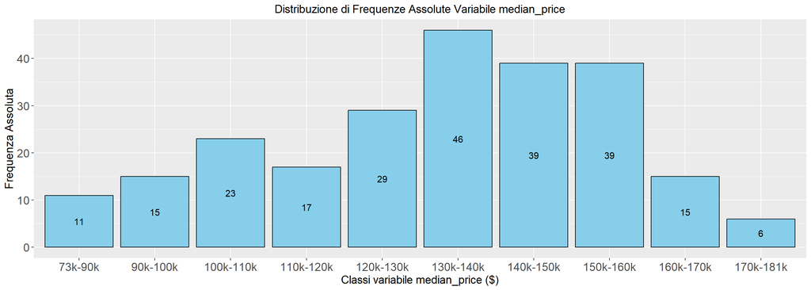

```r
print(grafico_freq_ass_median_price)
```

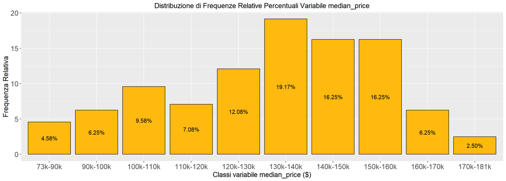

```r
print(grafico_freq_rel_median_price)
```

## 6-Indovina l’indice di gini per la variabile city

### L’indice di eterogenità di Gini per la variabile City è uguale a 1, dato che ogni città viene rappresentata con lo stesso numero di osservazioni, il che significa massima eterogeneità.

## 7-Qual è la probabilità che presa una riga a caso di questo dataset essa riporti la città “Beaumont”?

```r
city_probabilità = data %>%
  count(city) %>%
  mutate(probabilità = n / sum(n))

specifica_city = "Beaumont"
specifica_city_probabilità = city_probabilità %>%
  filter(city == specifica_city) %>%
  select(probabilità) %>%
  pull()

print(specifica_city_probabilità)
```

```
## [1] 0.25
```

## 7.1-E la probabilità che riporti il mese di Luglio?

```r
month_probabilità = data %>%
  count(month) %>%
  mutate(probabilità = n / sum(n))

specifica_month = "7"
specifica_month_probabilità = month_probabilità %>%
  filter(month == specifica_month) %>%
  select(probabilità) %>%
  pull()

print(specifica_month_probabilità)
```

```
## [1] 0.08333333
```

## 7.2-E la probabilità che riporti il mese di dicembre 2012?

```r
probabilità_mese = data %>%
  count(month) %>%
  mutate(probabilità_m = n / sum(n))


probabilità_anno = data %>%
  count(year) %>%
  mutate(probabilità_a= n / sum(n))

seleziona_mese = "12"
seleziona_anno = "2012"

# Filtrare per il mese e l'anno selezionati
probabilità_mese_selezionato = probabilità_mese %>%
  filter(month == seleziona_mese) %>%
  select(probabilità_m) %>%
  pull()

probabilità_anno_selezionato = probabilità_anno %>%
  filter(year == seleziona_anno) %>%
  select(probabilità_a) %>%
  pull()

# Calcolo della probabilità combinata
probabilità_combinata = probabilità_mese_selezionato * probabilità_anno_selezionato

# Stampa delle probabilità per il mese e l'anno specifici
cat("La probabilità che una riga presa a caso appartenga al mese", seleziona_mese, "e all'anno", seleziona_anno, "è:", probabilità_combinata, "\n")
```

```
## La probabilità che una riga presa a caso appartenga al mese 12 e all'anno 2012 è: 0.01666667
```

## 8-Esiste una colonna col prezzo mediano, creane una che indica invece il prezzo medio, utilizzando le altre variabili che hai a disposizione

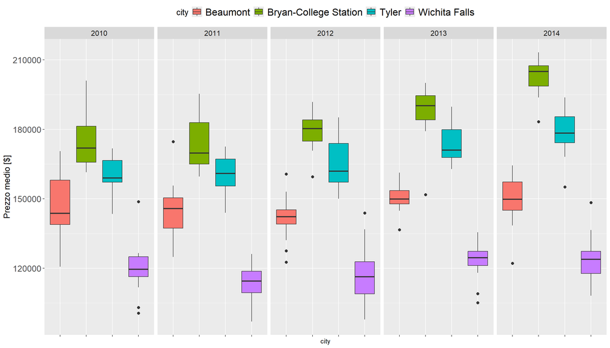

```r
mean_price = data %>%
  group_by(city,year,month) %>%
  mutate(calcolo_mean_price = (volume * 10^6) / sales) %>%
  ungroup()



grafico_prezzo_medio =ggplot(mean_price)+
  geom_boxplot(aes(city,calcolo_mean_price,fill=city),outlier.size = 2)+
  labs(y="Prezzo medio [$]")+
  facet_wrap(year,ncol=5)+
  theme(
    axis.text.x = element_blank(),
    axis.text.y = element_text(size = 14),
    axis.title.y = element_text(size = 14),
    legend.text = element_text(size = 16),
    legend.position = "top",
    legend.title = element_text(size = 14),
    strip.text = element_text(size = 12))

print(grafico_prezzo_medio)
```

## 9-Prova a creare un’altra colonna che dia un’idea di “efficacia” degli annunci di vendita. Riesci a fare qualche considerazione?

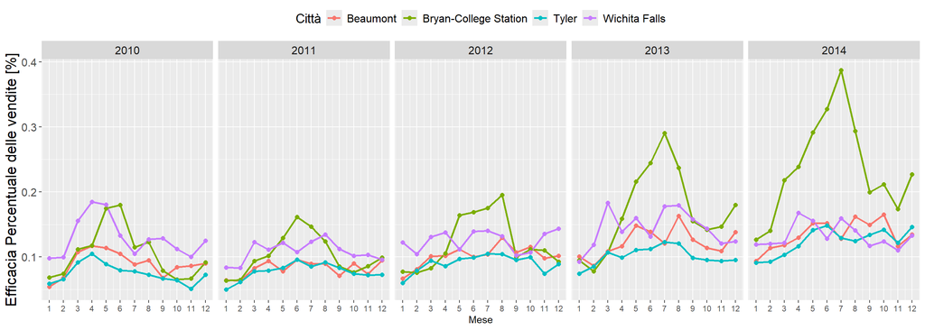

```r
efficacia = mean_price %>%
  group_by(city,year,month) %>%
  mutate(calcolo_efficacia = (sales / listings)) %>%
  ungroup()


linechart_efficacia = ggplot(efficacia, aes(x = month,y = calcolo_efficacia,color =city, group = interaction(city, year))) +
  geom_line(linewidth = 1) +
  geom_point(size = 2) +
  labs(
       x = "Mese",
       y = "Efficacia Percentuale delle vendite [%]",
       color = "Città") +
  scale_x_continuous(breaks = seq(1,12,1))+
  facet_wrap(~ year, ncol = 5, scales = "free_x") +
  theme(

    axis.text.y = element_text(size = 12),
    axis.title.y = element_text(size = 16),
    legend.text = element_text(size = 12),
    legend.title = element_text(size = 14),
    legend.position = "top",
    strip.text = element_text(size = 12))

barplot_listings = ggplot(efficacia, aes(x = month, y = listings, fill = city)) +
  geom_bar(stat = "identity",position = "dodge") +
  labs(
       x = "Mese",
       y = "Numero totale di annunci attivi",
       color = "Città") +
  scale_x_continuous(breaks = seq(1, 12, 1)) +
  facet_wrap(~ year, nrow = 1, scales = "free_x") +
  theme(
    axis.text.y = element_text(size = 12),
    axis.title.y = element_text(size = 14),
    legend.text = element_text(size = 12),
    legend.title = element_text(size = 14),
    legend.position = "top",
    strip.text = element_text(size = 12)
  )

barplot_sales = ggplot(efficacia, aes(x = month, y = sales, fill = city)) +
  geom_bar(stat = "identity",position = "dodge") +
  labs(
       x = "Mese",
       y = "Numero totale di vendite",
       color = "Città") +
  scale_x_continuous(breaks = seq(1, 12, 1)) +
  facet_wrap(~ year, nrow = 1, scales = "free_x") +
  theme(
    axis.text.y = element_text(size = 12),
    axis.title.y = element_text(size = 14),
    legend.text = element_text(size = 12),
    legend.title = element_text(size = 14),
    legend.position = "top",
    strip.text = element_text(size = 12)
  )

print(linechart_efficacia)
```

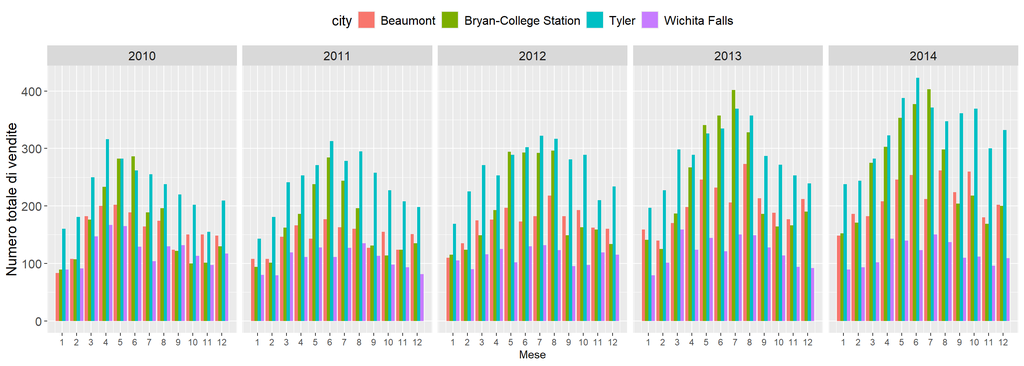

```r
print(barplot_sales)
```

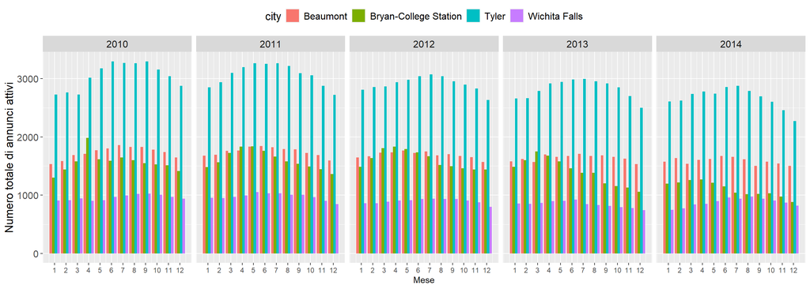

```r
print(barplot_listings)
```

### Indice di efficacia degli annunci di vendita.

##### L’indice di efficacia può variare da 0 (minima efficacia) ad 1(massima efficacia).

### Analisi e considerazioni

##### Wichita Falls mostra un andamento con molte oscillazioni. Nel 2010 si osserva un picco significativo nel primo semestre dell’anno.

##### Beaumont e Tyler hanno un comportamento abbastanza uniforme, con un andamento delle vendite piuttosto stabile e inferiore rispetto alle due altre città.

##### In generale l’efficacia delle vendite,nel periodo considerato, sembra aumentare nei mesi da maggio ad agosto.

## 10-Prova a creare dei summary(), o semplicemente media e deviazione standard, di alcune variabili a tua scelta, condizionatamente alla città, agli anni e ai mesi

```r
summary_city_year = data %>%
  group_by(city,year) %>%
  summarise(calcolo_media_volume=round(mean(volume),1),
            calcolo_sd_volume=round(sd(volume),1),
            calcolo_media_sales=round(mean(sales),1),
            calcolo_sd_sales=round(sd(sales),1),
            calcolo_media_listings=round(mean(listings),1),
            calcolo_sd_listings=round(sd(listings),1)) %>%
  ungroup()


summary_city_year %>%
  kable(
    col.names = c("Città", "Anno", "Media Volume", "sd.Volume",
                  "Media Sales", "sd.Sales",
                  "Media Listings", "sd.Listings"),
    align = "c"
  ) %>%
  kable_styling(
    full_width = FALSE,        # Tabella non a tutta larghezza
    bootstrap_options = c("striped", "hover", "condensed", "responsive")
  ) %>%
  row_spec(0, bold = TRUE, color = "white", background = "#2A3F54")  # Intestazione con stile personalizzato
```

| Città | Anno | Media Volume | sd.Volume | Media Sales | sd.Sales | Media Listings | sd.Listings |
| --- | --- | --- | --- | --- | --- | --- | --- |
| Beaumont | 2010 | 22.7 | 5.0 | 156.2 | 36.9 | 1731.1 | 101.9 |
| Beaumont | 2011 | 21.1 | 4.3 | 144.0 | 22.7 | 1747.9 | 74.7 |
| Beaumont | 2012 | 24.5 | 4.9 | 171.9 | 28.4 | 1691.3 | 54.6 |
| Beaumont | 2013 | 30.3 | 6.4 | 201.2 | 37.7 | 1639.6 | 54.9 |
| Beaumont | 2014 | 32.1 | 7.0 | 213.7 | 36.5 | 1586.7 | 57.4 |
| Bryan-College Station | 2010 | 28.7 | 10.8 | 167.6 | 70.8 | 1562.4 | 165.2 |
| Bryan-College Station | 2011 | 28.9 | 10.3 | 167.4 | 62.2 | 1606.2 | 156.1 |
| Bryan-College Station | 2012 | 35.4 | 13.5 | 196.8 | 74.3 | 1609.5 | 153.0 |
| Bryan-College Station | 2013 | 45.1 | 19.5 | 237.8 | 95.8 | 1406.1 | 228.4 |
| Bryan-College Station | 2014 | 52.8 | 18.0 | 260.2 | 86.7 | 1106.5 | 127.4 |
| Tyler | 2010 | 36.3 | 8.4 | 227.5 | 49.0 | 3051.1 | 226.4 |
| Tyler | 2011 | 38.6 | 9.4 | 238.8 | 49.6 | 3069.7 | 184.6 |
| Tyler | 2012 | 44.0 | 10.2 | 263.5 | 46.4 | 2910.4 | 123.0 |
| Tyler | 2013 | 50.3 | 10.3 | 287.4 | 53.0 | 2823.8 | 159.7 |
| Tyler | 2014 | 59.6 | 12.8 | 331.5 | 56.9 | 2670.3 | 172.2 |
| Wichita Falls | 2010 | 15.0 | 4.1 | 123.4 | 26.6 | 959.4 | 45.2 |
| Wichita Falls | 2011 | 12.1 | 2.5 | 106.2 | 19.8 | 974.8 | 58.6 |
| Wichita Falls | 2012 | 13.2 | 2.7 | 112.4 | 14.2 | 896.0 | 41.2 |
| Wichita Falls | 2013 | 14.9 | 3.1 | 121.2 | 26.0 | 841.0 | 52.9 |
| Wichita Falls | 2014 | 14.5 | 3.1 | 117.0 | 21.1 | 876.7 | 73.1 |

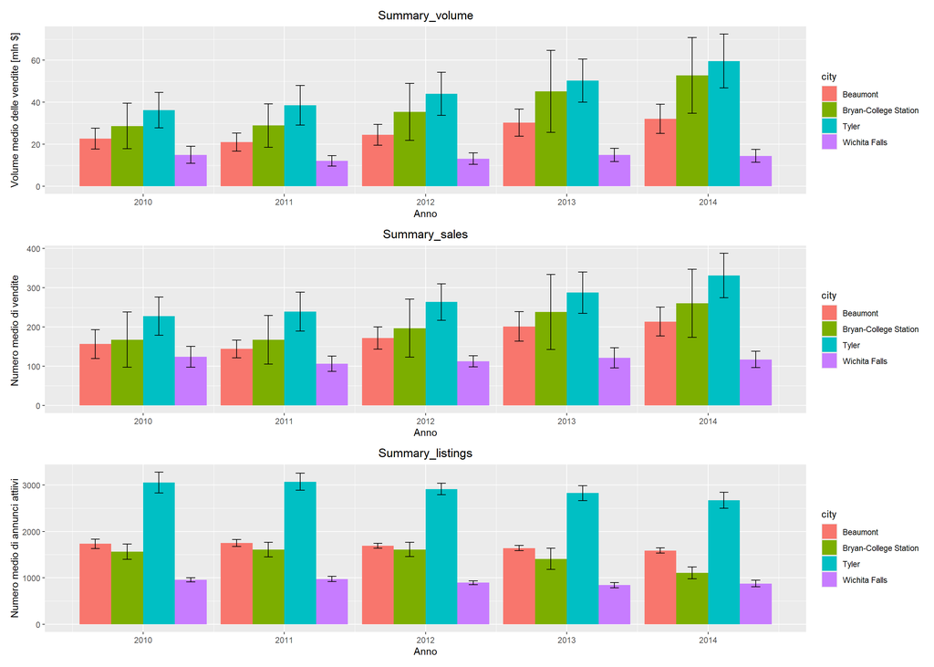

```r
summary_volume = ggplot(summary_city_year,aes(x=year,y=calcolo_media_volume,fill=city))+
  geom_bar(stat = "identity", position = "dodge") +
  geom_errorbar(aes(ymin = calcolo_media_volume - calcolo_sd_volume,
                    ymax = calcolo_media_volume + calcolo_sd_volume),
                position = position_dodge(0.9), width = 0.25) +
  labs(title = "Summary_volume", x = "Anno", y = "Volume medio delle vendite [mln $]") +
  theme(plot.title = element_text(hjust = 0.5))

summary_sales = ggplot(summary_city_year,aes(x=year,y=calcolo_media_sales,fill=city))+
  geom_bar(stat = "identity", position = "dodge") +
  geom_errorbar(aes(ymin = calcolo_media_sales - calcolo_sd_sales,
                    ymax = calcolo_media_sales + calcolo_sd_sales),
                position = position_dodge(0.9), width = 0.25) +
  labs(title = "Summary_sales", x = "Anno", y = "Numero medio di vendite ") +
  theme(plot.title = element_text(hjust = 0.5))

summary_listings = ggplot(summary_city_year,aes(x=year,y=calcolo_media_listings,fill=city))+
  geom_bar(stat = "identity", position = "dodge") +
  geom_errorbar(aes(ymin = calcolo_media_listings - calcolo_sd_listings,
                    ymax = calcolo_media_listings + calcolo_sd_listings),
               position = position_dodge(0.9), width = 0.25) +
  labs(title = "Summary_listings", x = "Anno", y = "Numero medio di annunci attiivi") +
  theme(plot.title = element_text(hjust = 0.5))

library(patchwork)

combined_plot = summary_volume/summary_sales/summary_listings +
  plot_layout(ncol = 1)

print(combined_plot)
```

## 11-Utilizza i boxplot per confrontare la distribuzione del prezzo mediano delle case tra le varie città. Commenta il risultato

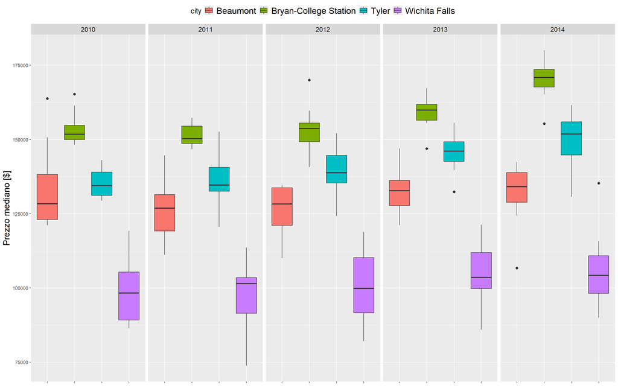

```r
boxplot_median_price = data %>%
  group_by(city,year,month) %>%
  summarise(median_price)


ggplot(boxplot_median_price)+
  geom_boxplot(aes(city,median_price,fill=city),outlier.size = 2)+
  labs(y="Prezzo mediano [$]")+
  facet_wrap(year,ncol=5)+
  theme(
    axis.text.x = element_blank(),
    axis.title.x = element_blank(),
    axis.title.y = element_text(size = 16),
    legend.text = element_text(size = 16),
    legend.position = "top",
    legend.title = element_text(size = 14),
    strip.text = element_text(size = 12)
  )
```

### Variabilità e Outlier

##### Wichita Falls ha una variabilità più ampia,soprattutto nel 2012.

##### Beaumont e Wichita Falls mostrano la presenza di outlier nel 2014 che si discostano molto dalla mediana.

### Confronto tra città

##### Bryan-College Station emerge come la città con i prezzi mediani più alti e una tendenza di crescita continua nel periodo considerato.

##### Wichita Falls ha costantemente i prezzi mediani più bassi, con una differenza significativa rispetto alle altre città.

##### Beaumont mostra gli andamenti più stabili ma con qualche fluttuazione.

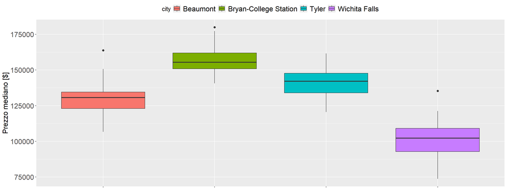

```r
ggplot(boxplot_median_price)+
  geom_boxplot(aes(city,median_price,fill=city),,outlier.size = 2)+
  labs(y="Prezzo mediano [$]")+
  theme(
    axis.text.x = element_blank(),
    axis.title.x = element_blank(),
    axis.text.y = element_text(size = 16),
    axis.title.y = element_text(size = 16),
    legend.text = element_text(size = 16),
    legend.position = "top",
    legend.title = element_text(size = 14),
    strip.text = element_text(size = 12)
  )
```

## 12-Utilizza i boxplot o qualche variante per confrontare la distribuzione del valore totale delle vendite tra le varie città ma anche tra i vari anni. Qualche considerazione da fare?

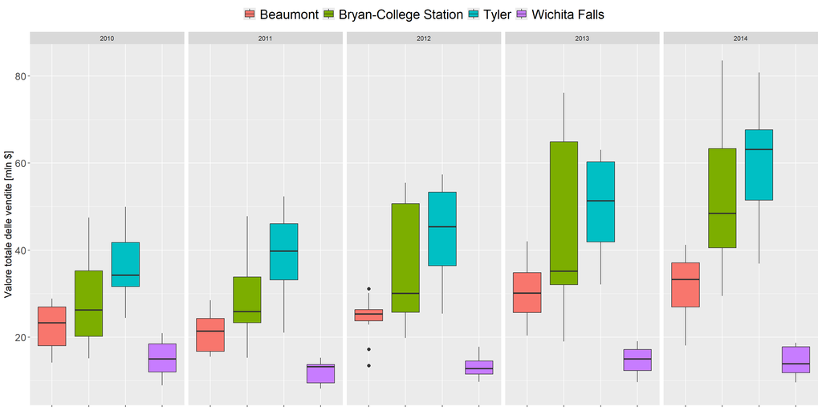

```r
ggplot(data)+
  geom_boxplot(aes(city,volume, fill=city),outlier.size = 2)+
  labs(y="Valore totale delle vendite [mln $]")+
  facet_wrap(year,ncol = 5)+
  theme(
    axis.text.x = element_blank(),
    axis.title.x = element_blank(),
    axis.title.y = element_text(size=14),
    axis.text.y = element_text(size=14),
    legend.title = element_blank(),
    legend.text = element_text(size = 18),
    legend.position = "top"

  )
```

### Distribuzione del valore totale delle vendite

##### Beaumont ha una distribuzione del valore totale delle vendite con una tendenza crescente dopo il calo del 2011.

##### Bryan-College Station mostra una tendenza crescente dopo la flessione del 2011.

##### Tyler mostra una tendenza sempre crescente nell’arco di tempo considerato.

##### Wichita Falls mostra una distribuzione significativamente più bassa rispetto alle altre città con un divario che aumenta nell’arco degli anni.

### Variabilità e Outlier

##### Tyler ha una variabilità crescente significativa che sembra però stabilizzarsi nel triennio 2012-2014.

##### Beaumont ha una variabilità costante con un mindimo significativo nel 2012. In questo anno sono però da segnalare 3 diversi outlier. Includendo questi outlier all’interno della distribuzione la variabilità potrebbe risultare maggiore.

##### Wichita Falls ha una bassa variabilità legata presumibilmente ad un mercato immobiliare non particolarmente dinamico.

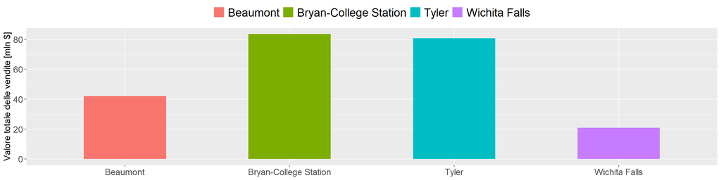

```r
ggplot(data)+
  geom_bar(aes(city,volume,fill=city),
           position = "dodge",
           stat = "identity",
           width = 0.5)+
  labs(y="Valore totale delle vendite [mln $]")+
  theme(
    #panel.spacing.x = unit(1, "lines"),
    axis.title.x = element_blank(),
    axis.title.y = element_text(size=14),
    axis.text.x = element_text(size=14),
    axis.text.y = element_text(size=14),
    legend.title = element_blank(),
    legend.text = element_text(size = 18),
    legend.position = "top"
)
```

## 13 Usa un grafico a barre sovrapposte per confrontare il totale delle vendite nei vari mesi, sempre considerando le città. Prova a commentare ciò che viene fuori.

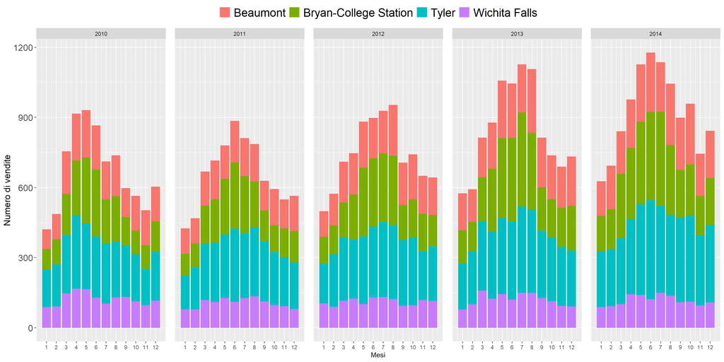

```r
ggplot(data)+
  geom_bar(aes(month,sales,fill=city),
           position = "stack",
           stat = "identity")+
  labs(x="Mesi",y="Numero di vendite")+
  scale_x_continuous(breaks = seq(1,12,1))+
  facet_wrap(year,ncol=5)+
  theme(
    panel.spacing.x = unit(1, "lines"),
    axis.title.y = element_text(size=14),
    axis.text.y = element_text(size=14),
    legend.title = element_blank(),
    legend.text = element_text(size = 18),
    legend.position = "top"
)
```

## 13.1 Già che ci sei prova anche il grafico a barre normalizzato

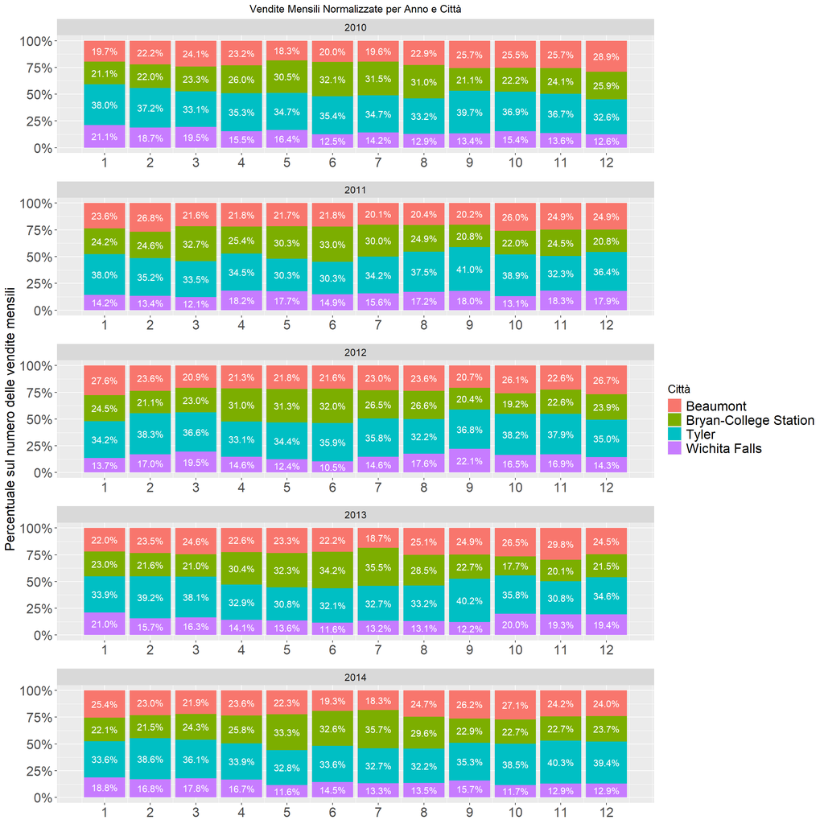

```r
# Aggregare e normalizzare i dati
sales_normalizzato = data %>%
  group_by(year, month, city) %>%
  summarise(somma_sales = sum(sales, na.rm = TRUE)) %>%
  ungroup() %>%
  group_by(year, month) %>%
  mutate(percentuale = somma_sales / sum(somma_sales) * 100) %>%
  ungroup()

# Creare il grafico a barre normalizzato con facet_wrap e etichette di percentuale
grafico_sales_normalizzato=ggplot(sales_normalizzato, aes(x = month, y = percentuale, fill = city)) +
  geom_bar(position = "stack", stat = "identity") +
  geom_text(aes(label = sprintf("%.1f%%", percentuale)),
            position = position_stack(vjust = 0.5),
            size = 4,
            color = "white") +
  labs(title = "Vendite Mensili Normalizzate per Anno e Città",
       y = "Percentuale sul numero delle vendite mensili", fill = "Città") +
  scale_y_continuous(labels = scales::percent_format(scale = 1)) +
  scale_x_continuous(breaks = seq(1,12,1))+
  facet_wrap(year, ncol = 1, scales = "free_x")+
  theme(
    axis.text.x = element_text(size=16),
    axis.text.y = element_text(size = 16),
    axis.title.x = element_blank(),
    axis.title.y = element_text(size = 16),
    legend.text = element_text(size = 16),
    legend.title = element_text(size = 14),
    strip.text = element_text(size = 12),
    plot.title = element_text(hjust = 0.5),
    panel.spacing = unit(1, "lines"))

grafico_sales_normalizzato
```

## 14-Prova a creare una line chart di una variabile a tua scelta per fare confronti commentati fra le città e periodi storici.

```r
serie_storica_volume = data %>%
  group_by(city,year,month) %>%
  summarise(volume_linechart = mean(volume)) %>%
  ungroup()


linechart_serie_storica_volume = ggplot(serie_storica_volume, aes(x = month, y = volume_linechart,color =city, group = interaction(city, year))) +
  geom_line(linewidth = 1) +
  geom_point(size = 2) +
  labs(
       x = "Month",
       y = "Valore delle vendite [mln $]",
       color = "Città") +
  scale_x_continuous(breaks = seq(1,12,1))+
  facet_wrap(~ year, ncol = 5, scales = "free_x") +
  theme(
    axis.text.x = element_text(hjust = 1),
    axis.text.y = element_text(size = 12),
    axis.title.y = element_text(size = 14),
    legend.text = element_text(size = 12),
    legend.title = element_text(size = 14),
    legend.position = "top",
    strip.text = element_text(size = 12)
  )
```

```r
serie_storica_sales = data %>%
  group_by(city,year,month) %>%
  summarise(sales_linechart = mean(sales)) %>%
  ungroup()


linechart_serie_storica_sales = ggplot(serie_storica_sales, aes(x = month, y = sales_linechart,color =city, group = interaction(city, year))) +
  geom_line(linewidth = 1) +
  geom_point(size = 2) +
  labs(
       x = "Mesi",
       y = "Numero di vendite",
       color = "Città") +
  scale_x_continuous(breaks = seq(1,12,1))+
  facet_wrap(~ year, ncol = 5, scales = "free_x") +
  theme(
    axis.text.x = element_text(hjust = 1),
    axis.text.y = element_text(size = 12),
    axis.title.y = element_text(size = 14),
    legend.text = element_text(size = 12),
    legend.title = element_text(size = 14),
    legend.position = "top",
    strip.text = element_text(size = 12)
  )
```

```r
serie_storica_median_price = data %>%
  group_by(city,year,month) %>%
  summarise(median_price_linechart = mean(median_price)) %>%
  ungroup()


linechart_serie_storica_median_price = ggplot(serie_storica_median_price, aes(x = month, y = median_price_linechart,color =city, group = interaction(city, year))) +
  geom_line(linewidth = 1) +
  geom_point(size = 2) +
  labs(
       x = "Mesi",
       y = "Prezzo mediano di vendita [$]",
       color = "Città") +
  scale_x_continuous(breaks = seq(1,12,1))+
  facet_wrap(~ year, ncol = 5, scales = "free_x") +
  theme(
    axis.text.x = element_text(hjust = 1),
    axis.text.y = element_text(size = 12),
    axis.title.y = element_text(size = 14),
    legend.text = element_text(size = 12),
    legend.title = element_text(size = 14),
    legend.position = "top",
    strip.text = element_text(size = 12)
  )
```

```r
serie_storica_listings= data %>%
  group_by(city,year,month) %>%
  summarise(listings_linechart = mean(listings)) %>%
  ungroup()


linechart_serie_storica_listings = ggplot(serie_storica_listings, aes(x = month, y = listings_linechart,color =city, group = interaction(city, year))) +
  geom_line(linewidth = 1) +
  geom_point(size = 2) +
  labs(
       x = "Mesi",
       y = "Numero di annunci attivi",
       color = "Città") +
  scale_x_continuous(breaks = seq(1,12,1))+
  facet_wrap(~ year, ncol = 5, scales = "free_x") +
  theme(
    axis.text.x = element_text(hjust = 1),
    axis.text.y = element_text(size = 12),
    axis.title.y = element_text(size = 14),
    legend.text = element_text(size = 12),
    legend.title = element_text(size = 14),
    legend.position = "top",
    strip.text = element_text(size = 12)
  )
```

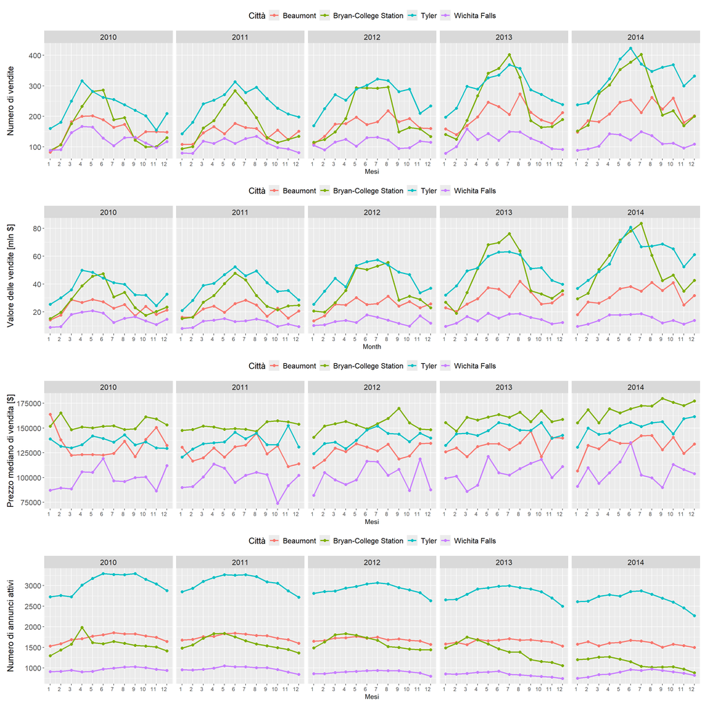

```r
linechart_serie_storica_sales / linechart_serie_storica_volume / linechart_serie_storica_median_price / linechart_serie_storica_listings
```

##### Wichita Falls è costantemente la città con le metriche più basse. La causa potrebbe essere attribuita in prima approssimazione ad una scarsa offerta di immobili che si ripercuote a cascata sul volume di fatturato.